# Results Visualisation

# Introduction

This vignette demonstrates how to use table and plotting functions provided by **MeasurementDiagnostics** to visualise results.

We use the package mock data so examples are fully reproducible.

```r
library(MeasurementDiagnostics)
library(dplyr)
library(omopgenerics)
library(ggplot2)

cdm <- mockMeasurementDiagnostics()

# Example codelist we'll use in the examples
alkaline_phosphatase_codes <- list("alkaline_phosphatase" = c(3001467L, 45875977L))
```

# Create diagnostics results

We call `summariseMeasurementUse()` once and obtain histogram bins for all numeric variables. This returns a `summarised_result` containing all the diagnostics checks, summary estimates, and density and histogram estimates to visualise distributions of numeric variables; all for the overall measurements codelist and stratified by sex.

```r
result <- summariseMeasurementUse(
  cdm = cdm,
  codes = alkaline_phosphatase_codes,
  bySex = TRUE,
  byYear = FALSE,
  byConcept = FALSE,
  histogram = list(
    days_between_measurements = list(
      "0-30" = c(0, 30), "31-90" = c(31, 90), "91-365" = c(91, 365), "366+" = c(366, Inf)
    ),
    measurements_per_subject = list(
      "0" = c(0, 0), "1" = c(1, 1), "2-3" = c(2, 3), "4+" = c(4, 1000)
    ),
    value_as_number = list(
      "low" = c(0, 5.999), "mid" = c(6, 10.999), "high" = c(11, Inf)
    )
  )
)
```

# Tables

There is one table function corresponding to each diagnostic check:

- `tableMeasurementSummary()` — subjects with measurements, counts per subject, days between measurements.
- `tableMeasurementValueAsNumber()` — numeric value summaries (by unit where available).
- `tableMeasurementValueAsConcept()` — frequency of concept values.

You can customise which columns appear in the *header*, which are used as *grouping columns*, and which to *hide*.

```r
# 1. Measurement summary table (timings / counts)
tableMeasurementSummary(
  result,
  header = c("codelist_name", "sex"),
  hide = c("cdm_name", "domain_id")
)
```

| Variable name | Variable level | Estimate name | Codelist name alkaline_phosphatase Sex overall | Codelist name alkaline_phosphatase Sex Female | Codelist name alkaline_phosphatase Sex Male |
| --- | --- | --- | --- | --- | --- |
| Number subjects | – | N (%) | 67 (67.00%) | 40 (40.00%) | 27 (27.00%) |
| Days between measurements | – | Median [Q25 – Q75] | 249 [67 – 645] | 240 [53 – 1,133] | 267 [81 – 415] |
|  |  | Range | 8 to 2,886 | 8 to 2,886 | 8 to 2,743 |
| Measurements per subject | – | Median [Q25 – Q75] | 1.00 [1.00 – 2.00] | 1.00 [1.00 – 2.00] | 1.00 [1.00 – 2.00] |
|  |  | Range | 1.00 to 4.00 | 1.00 to 4.00 | 1.00 to 3.00 |

```r
# 2. Numeric-value summary table (values recorded as numbers)
tableMeasurementValueAsNumber(result)
```

| CDM name | Unit concept name | Unit concept ID | Variable name | Estimate name | Sex overall | Sex Female | Sex Male |
| --- | --- | --- | --- | --- | --- | --- | --- |
| alkaline_phosphatase |  |  |  |  |  |  |  |
| mock database | kilogram | 9529 | Measurement records | N | 50 | 33 | 17 |
|  |  |  | Value as number | Median [Q25 – Q75] | 8.77 [7.07 – 10.48] | 8.12 [6.60 – 10.22] | 9.13 [8.26 – 11.17] |
|  |  |  |  | Q05 – Q95 | 5.70 – 11.84 | 5.58 – 11.60 | 6.64 – 11.83 |
|  |  |  |  | Q01 – Q99 | 5.43 – 12.11 | 5.41 – 11.99 | 6.08 – 12.11 |
|  |  |  |  | Range | 5.36 to 12.18 | 5.36 to 12.04 | 5.94 to 12.18 |
|  |  |  |  | Missing value, N (%) | 2 (4.00%) | 2 (6.06%) | 0 (0.00%) |
|  | NA | - | Measurement records | N | 50 | 27 | 23 |
|  |  |  | Value as number | Median [Q25 – Q75] | 8.77 [7.10 – 10.44] | 8.55 [6.85 – 10.01] | 8.92 [7.39 – 10.88] |
|  |  |  |  | Q05 – Q95 | 5.77 – 11.77 | 5.75 – 11.32 | 6.18 – 11.80 |
|  |  |  |  | Q01 – Q99 | 5.50 – 12.04 | 5.61 – 11.94 | 5.59 – 11.93 |
|  |  |  |  | Range | 5.44 to 12.11 | 5.58 to 12.11 | 5.44 to 11.96 |
|  |  |  |  | Missing value, N (%) | 3 (6.00%) | 3 (11.11%) | 0 (0.00%) |

```r
# 3. Concept-value summary table (values recorded as concepts)
tableMeasurementValueAsConcept(result)
```

| CDM name | Variable name | Value as concept name | Value as concept ID | Estimate name | Sex overall | Sex Female | Sex Male |
| --- | --- | --- | --- | --- | --- | --- | --- |
| alkaline_phosphatase |  |  |  |  |  |  |  |
| mock database | Measurement records | Low | 4267416 | N (%) | 34 (34.00%) | 16 (26.67%) | 18 (45.00%) |
|  |  | High | 4328749 | N (%) | 33 (33.00%) | 26 (43.33%) | 7 (17.50%) |
|  |  | NA | NA | N (%) | 33 (33.00%) | 18 (30.00%) | 15 (37.50%) |

# Plots

The plotting helpers allow to plot certain types of graphics, while giving flexibility for variables to use for colouring, facetting, and which to have in the horizontla and vertical axes. They return `ggplot` objects, which allows further customisation using standard [**ggplot2**](https://ggplot2.tidyverse.org) layers.

## Measurement summary

`plotMeasurementSummary()` visualises `days_between_measurements`, and `measurements_per_subject`. Supported plot type are `"boxplot"`, `"barplot"`, and `"densityplot"`.

The variable specified in `y` must be either “days_between_measurements” or “measurements_per_subject” as it is used to filter which of the summary results to plot.

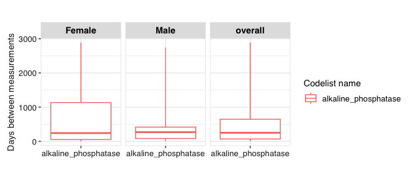

```r
result |>
  plotMeasurementSummary(
    x = "codelist_name",
    y = "days_between_measurements",
    plotType = "boxplot"
  )
```

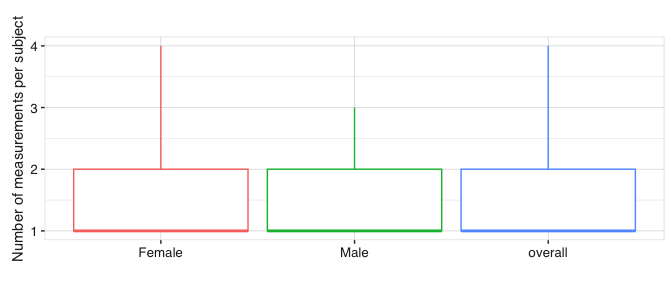

```r
result |>
  plotMeasurementSummary(
    x = "sex",
    y = "measurements_per_subject",
    plotType = "boxplot",
    colour = "sex",
    facet = NULL
  ) +
  theme(legend.position = "none")
```

If we got `density` estimates we can also use `densityplot` for these variables. To choose which variable to plot, we use the `y` argument, while the `x` argument is ignored for this plot type.

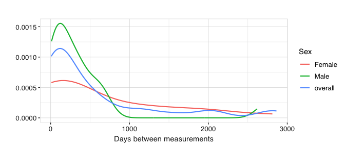

```r
result |>
  plotMeasurementSummary(
    plotType = "densityplot",
    colour = "sex",
    facet = NULL
  )
```

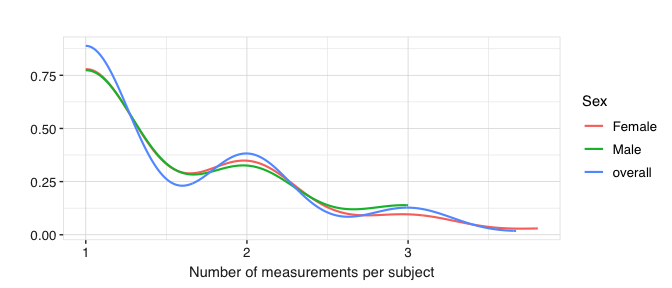

```r
result |>
  plotMeasurementSummary(
    y = "measurements_per_subject",
    plotType = "densityplot",
    colour = "sex",
    facet = NULL
  )
```

Since we got specific bin-counts to plot histograms for these variables, we can also use `plotType = "barplot"`

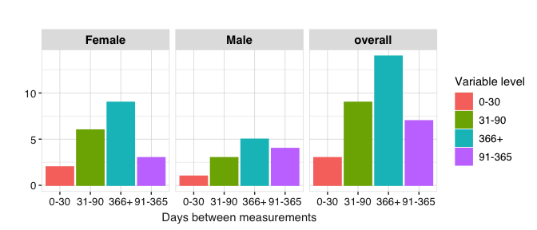

```r
result |>
  plotMeasurementSummary(
    x = "variable_level",
    plotType = "barplot",
    colour = "variable_level",
    facet = "sex"
  )
```

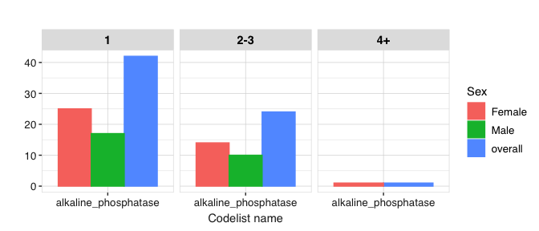

```r
result |>
  plotMeasurementSummary(
    y = "measurements_per_subject",
    plotType = "barplot",
    colour = "sex",
    facet = "variable_level"
  )
```

## Numeric-value summary

`plotMeasurementValueAsNumber()` visualises distributions of numeric measurement values. We demonstrate the three plot types, similar to the measurement summary plots.

### boxplot

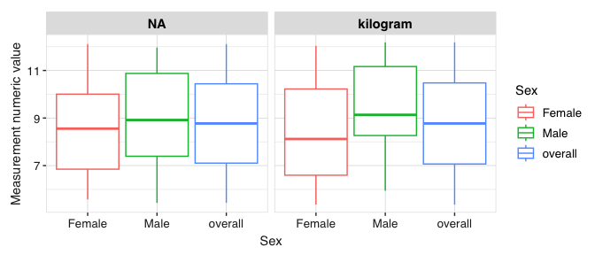

```r
result |>
  plotMeasurementValueAsNumber(
    x = "sex",
    plotType = "boxplot",
    facet = "unit_concept_name",
    colour = "sex"
  )
```

### densityplot

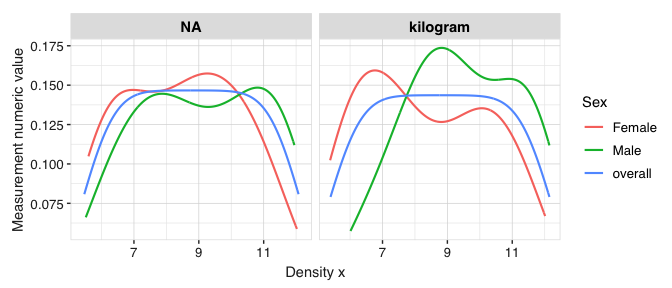

```r
result |>
  plotMeasurementValueAsNumber(
    plotType = "densityplot",
    facet = "unit_concept_name",
    colour = "sex"
  )
```

### barplot

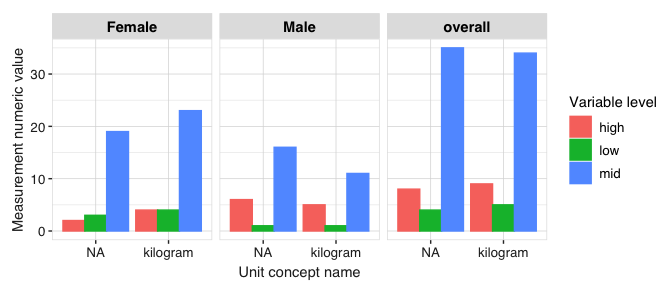

```r
result |>
  plotMeasurementValueAsNumber(
    x = "unit_concept_name",
    plotType = "barplot",
    facet = c("sex"),
    colour = "variable_level"
  )
```

## Concept-value summary

`plotMeasurementValueAsConcept()` visualises concept-coded measurement values and their frequencies. Next we plot counts for each concept value in the codelist.

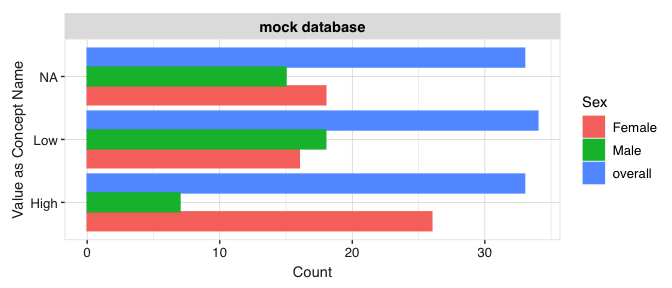

```r
result |>
  plotMeasurementValueAsConcept(
    x = "count",
    y = "variable_level",
    facet = "cdm_name",
    colour = "sex"
  ) +
  ylab("Value as Concept Name")
```

Instead of counts, we can also plot the percentage for each concept:

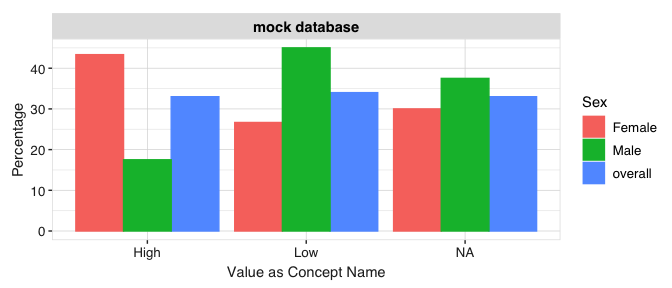

```r
result |>
  plotMeasurementValueAsConcept(
    x = "variable_level",
    y = "percentage",
    facet = "cdm_name",
    colour = "sex"
  ) +
  xlab("Value as Concept Name")
```

# Visualisation with other packages

## Shiny Apps with OmopViewer

The [**OmopViewer**](https://ohdsi.github.io/OmopViewer/) package supports results produced by **MeasurementDiagnostics** and provides a user-friendly way to quickly generate a Shiny application to explore diagnostic results in an interactive way.

For example, the following code exports a static Shiny app that allows users to navigate the tables and plots generated in this vignette.

```r
library(OmopViewer)
exportStaticApp(result = result, directory = tempdir())
```

## Customisation of plots and tables with visOmopResults

Tables and plots in **MeasurementDiagnostics** are generated using the [**visOmopResults**](https://darwin-eu.github.io/visOmopResults/) package. Users who wish to create custom tables or visualisations directly from a `summarised_result` object can do so by leveraging the functions provided by this package.

## Application of MeasurementDiagnostics in PhenotypeR

**MeasurementDiagnostics** is integrated into the [**PhenotypeR**](https://ohdsi.github.io/PhenotypeR/) package. When cohorts are defined based on measurement codes, **PhenotypeR** automatically applies `summariseCohortMeasurementUse()` to generate measurement diagnostics during cohort construction, using the codelists linked to each cohort.

This integration allows users to assess measurement codelists and cohorts as part of a broader phenotype development workflow.